# 1. Getting Started

Author: Arianna Basile, MRC Toxicology Unit, University of Cambridge

In this tutorial:

- You will use the library cobrapy to import a metabolic reconstruction (1.1)
- Inspect the reactions of your model (1.2)
- Inspect the metabolites in your model (1.3)
- Inspect the genes in your model (1.4)
- Perform in-silico gene knockout experiments (1.4.1)
- Do additional exercises

```python
#import the needed packages
import cobra

#enable autocompleting with tab
%config Completer.use_jedi = False
```

## 1.1 Import a reconstruction

The Systems Biology Markup Language is an XML-based standard format for distributing models which has support for COBRA models through the FBC extension version 2.

Cobrapy has native support for reading and writing SBML with FBCv2. Please note that all id’s in the model must conform to the SBML SID requirements in order to generate a valid SBML file.

Let's download and import the model of [Saccharomyces cerevisiae](http://bigg.ucsd.edu/search?query=Saccharomyces+cerevisiae+S288C)

```python
model_yeast=cobra.io.read_sbml_model("iMM904.xml.gz")
```

The reactions, metabolites, and genes attributes of the cobrapy model are a special type of list called a cobra.DictList, and each one is made up of cobra.Reaction, cobra.Metabolite and cobra.Gene objects respectively.

```python
print(len(model_yeast.reactions))
print(len(model_yeast.metabolites))
print(len(model_yeast.genes))
```

```
1577
1226
905
```

When using Jupyter notebook this type of information is rendered as a table.

```python
model_yeast
```

| **Name** | iMM904 |
| --- | --- |
| **Memory address** | 0x07f81f3e65ac0 |
| **Number of metabolites** | 1226 |
| **Number of reactions** | 1577 |
| **Number of groups** | 0 |
| **Objective expression** | 1.0*BIOMASS_SC5_notrace - 1.0*BIOMASS_SC5_notrace_reverse_93090 |
| **Compartments** | cytosol, extracellular space, mitochondria, peroxisome/glyoxysome, endoplasmic reticulum, vacuole, golgi apparatus, nucleus |

Just like a regular list, objects in the DictList can be retrieved by index. For example, to get the 3rd reaction in the model (at index 2nd because of 0-indexing):

```python
model_yeast.reactions[2]
```

| **Reaction identifier** | 13BGHe |
| --- | --- |
| **Name** | Exo 1 3 beta glucan glucohydrase |
| **Memory address** | 0x07f8200722310 |
| **Stoichiometry** | 13BDglcn_e + h2o_e --> glc__D_e 1 3 beta D Glucan C6H10O5 + H2O H2O --> D-Glucose |
| **GPR** | YOR190W or YDR261C or YLR300W |
| **Lower bound** | 0.0 |
| **Upper bound** | 999999.0 |

Additionally, items can be retrieved by their id using the DictList.get_by_id() function. For example, to get the cytosolic atp metabolite object (the id is “atp_c”), we will inspect metabolites in the section 1.3 For the moment, we can focus on the reactions of our model.

## 1.2 Reactions

We will consider the reaction glucose 6-phosphate isomerase, which interconverts glucose 6-phosphate and fructose 6-phosphate. The reaction id for this reaction in our test model is PGI. However, if you want to see the iDs of all the reactions in the reconstruction, you can run the code below:

```python
reaction_ids = [reaction.id for reaction in model_yeast.reactions]
reaction_ids
```

```
['CITtcp',
 '13BGH',
 '13BGHe',
 '13GS',
 '16GS',
 '23CAPPD',
 '2DDA7Ptm',
 '2DHPtm',
 '2DOXG6PP',
 '2HBO',
 '2HBt2',
 '2HMHMBQMTm',
 '2HP6MPMOm',
 '2HPMBQMTm',
 '2HPMMBQMOm',
 '2MBACt',
 'EX_epistest_SC_e',
 'EX_epist_e',
 '2MBALDt',
 '2MBALDtm',
 '2MBTOHt',
 'ACACT6p',
 '2MBTOHtm',
 'ACACT7p',
 '2MPPALt',
 'ACACT8p',
 'ACACT9p',
 'ACALDCD',
 'ACALDt',
 'ACALDtm',
 'ACCOAC',
 'ACCOACrm',
 'AGAT_SC',
 'AGPRim',
 'AGTi',
 'AHCYStm',
 'ACCOAtn',
 '2MPPALtm',
 'ACESt',
 'ACGAM6PS',
```

[output cut: 946 more lines]

```
 'LEUTRSm',
 'ID3ACALDt',
 'ID3ACALDtm',
 'IG3PS',
 'IGPDH',
 'IGPS',
 'ILETA',
 'ILETAm',
 'ILETRS',
 'ILETRSm',
 'ILEt2r',
 'ILEt6',
 'ILEt7',
 'LEUt2r',
 ...]
```

Now, let's focus on PGI or another reaction of your choice:

```python
pgi = model_yeast.reactions.get_by_id("PGI")
pgi
```

| **Reaction identifier** | PGI |
| --- | --- |
| **Name** | Glucose-6-phosphate isomerase |
| **Memory address** | 0x07f8200fd6f40 |
| **Stoichiometry** | g6p_c <=> f6p_c D-Glucose 6-phosphate <=> D-Fructose 6-phosphate |
| **GPR** | YBR196C |
| **Lower bound** | -999999.0 |
| **Upper bound** | 999999.0 |

We can view the full name and reaction catalyzed as strings.

```python
print(pgi.name)
print(pgi.reaction)
```

```
Glucose-6-phosphate isomerase
g6p_c <=> f6p_c
```

We can also view reaction upper and lower bounds, large numbers, typically around 1000 or more, are used as infinite limits (unconstained fluxes). Because the pgi.lower_bound < 0, and pgi.upper_bound > 0, pgi is reversible.

```python
print(pgi.lower_bound, "< pgi <", pgi.upper_bound)
print(pgi.reversibility)
```

```
-999999.0 < pgi < 999999.0
True
```

The lower and upper bound of reactions can also be modified, and the reversibility attribute will automatically be updated. The preferred method for manipulating bounds is using reaction.bounds, e.g.

```python
old_bounds = pgi.bounds
pgi.bounds = (0, 1000.0)
print(pgi.lower_bound, "< pgi <", pgi.upper_bound)
print("Reversibility after modification:", pgi.reversibility)
pgi.bounds = old_bounds
print("Reversibility after resetting:", pgi.reversibility)
```

```
0 < pgi < 1000.0
Reversibility after modification: False
Reversibility after resetting: True
```

We can also ensure the reaction is mass balanced. This function will return elements which violate mass balance. If it comes back empty, then the reaction is mass balanced.

```python
pgi.check_mass_balance()
```

```
{}
```

In order to add a metabolite, we pass in a dictionary with the metabolite object and its coefficient

```python
pgi.add_metabolites({model_yeast.metabolites.get_by_id("h_c"): -1})
pgi.reaction
```

```
'g6p_c + h_c <=> f6p_c'
```

The reaction is no longer mass balanced

```python
pgi.check_mass_balance()
```

```
{'charge': -1.0, 'H': -1.0}
```

We can remove the metabolite, and the reaction will be balanced once again.

```python
pgi.subtract_metabolites({model_yeast.metabolites.get_by_id("h_c"): -1})
print(pgi.reaction)
print(pgi.check_mass_balance())
```

```
g6p_c <=> f6p_c
{}
```

## 1.3 Metabolites

We will consider cytosolic atp as our metabolite, which has the id "atp_c" in our test model. However, if you want to see the iDs of all the metabolites in the reconstruction, you can run the code below:

```python
metabolite_ids = [metabolite.id for metabolite in model_yeast.metabolites]
metabolite_ids
```

```
['2dr5p_c',
 '2hb_c',
 '2hb_e',
 '2hhxdal_c',
 '2hp6mbq_m',
 '2hp6mp_m',
 '2hpmhmbq_m',
 '2hpmmbq_m',
 '2ippm_c',
 '2kmb_c',
 '2mahmp_c',
 '2mbac_c',
 '2mbac_e',
 '2mbald_c',
 '2mbald_e',
 '2mbald_m',
 '2mbtoh_c',
 '2mbtoh_e',
 '2mbtoh_m',
 '2mcit_m',
 '2mppal_c',
 '2mppal_e',
 '2mppal_m',
 '2obut_c',
 '2obut_m',
 '2oxoadp_c',
 '2oxoadp_m',
 '2pg_c',
 '2phetoh_c',
 '2phetoh_e',
 '2phetoh_m',
 '10fthf_c',
 '34hpl_m',
 '34hpp_c',
 '34hpp_m',
 '10fthf_m',
 '4fumacac_c',
 '34hpp_x',
 '35ccmp_c',
 '4gudbd_c',
```

[output cut: 946 more lines]

```
 'sql_r',
 'pap_x',
 'ptd1ino_SC_n',
 'paps_c',
 'srb__L_c',
 'ptd2meeta_SC_c',
 'srb__L_e',
 'stcoa_c',
 'pc_SC_c',
 'ptd3ino_SC_c',
 'pc_SC_e',
 'stcoa_x',
 'ptd4ino_SC_c',
 'succ_c',
 ...]
```

Now, let's focus on atp_c or another metabolite of your choice:

```python
atp = model_yeast.metabolites.get_by_id("atp_c")
atp
```

| **Metabolite identifier** | atp_c |
| --- | --- |
| **Name** | ATP C10H12N5O13P3 |
| **Memory address** | 0x07f81e28a38b0 |
| **Formula** | C10H12N5O13P3 |
| **Compartment** | c |
| **In 149 reaction(s)** | BIOMASS_SC5_notrace, DURIK1, GLUCYS, LYSTRS, HMPK1, CYTK1, DHFS, PRAIS, GSNK, SADT, DADK, PRAGSr, CYSTRS, RBK, ADK1, GMPS2, FACOAL140, AASAD2, FACOAL161, DPCOAK, ARGTRS, ASNS1, GLYK, DRBK, NDPK1,... |

We can print out the metabolite name and compartment (cytosol in this case) directly as string.

```python
print(atp.name)
print(atp.compartment)
```

```
ATP C10H12N5O13P3
c
```

We can see that ATP is a charged molecule in our model.

```python
atp.charge
```

```
-4
```

We can see the chemical formula for the metabolite as well.

```python
print(atp.formula)
```

```
C10H12N5O13P3
```

## 1.4 Genes

The gene_reaction_rule is a boolean representation of the gene requirements for this reaction to be active as described in [Schellenberger et al 2011 Nature Protocols 6(9):1290-307](https://www.nature.com/articles/nprot.2011.308).

The GPR is stored as the GPR class in the gpr for a Reaction. A string representation of it is stored as the gene_reaction_rule for a Reaction object.

```python
gpr_string = pgi.gene_reaction_rule
print(gpr_string)
```

```
YBR196C
```

Corresponding gene objects also exist. These objects are tracked by the reactions itself, as well as by the model

```python
pgi_gene = model_yeast.genes.get_by_id("YBR196C")
pgi_gene
```

| **Gene identifier** | YBR196C |
| --- | --- |
| **Name** | PGI1 |
| **Memory address** | 0x07f81f41786d0 |
| **Functional** | True |
| **In 3 reaction(s)** | G6PI, PGI, G6PI3 |

Let's check this gene also on KEGG database to assess the consistency of the metabolic reconstruction --> [HERE](https://www.genome.jp/entry/sce:YBR196C)

### 1.4.1 Simulating Knockouts

The delete_model_genes function will evaluate the GPR and set the upper and lower bounds to 0 if the reaction is knocked out.

```python
model_yeast=cobra.io.read_sbml_model("iMM904.xml.gz")
pgi=model_yeast.reactions.get_by_id("PGI")
print("before KO: %4d < flux_PGI < %4d" % (pgi.lower_bound, pgi.upper_bound))


gene=model_yeast.genes.get_by_id("YBR196C")
gene.knock_out()
print("after KO: %4d < flux_PGI < %4d" % (pgi.lower_bound, pgi.upper_bound))
```

```
before KO: -999999 < flux_PGI < 999999
after KO:    0 < flux_PGI <    0
```

Quite often, one wants to make small changes to a model and evaluate the impacts of these. For example, we may want to knock-out all reactions sequentially, and see what the impact of this is on the objective function. One way of doing this would be to create a new copy of the model before each knock-out with model.copy(). However, even with small models, this is a very slow approach as models are quite complex objects. Better then would be to do the knock-out, optimizing and then manually resetting the reaction bounds before proceeding with the next reaction. Since this is such a common scenario however, cobrapy allows us to use the model as a context, to have changes reverted automatically.

```python
#we import the model again to reverse the previous edits
model_yeast=cobra.io.read_sbml_model("iMM904.xml.gz")

#we simulate knockouts of single reactions
model_yeast.optimize()
print(model_yeast.objective.value)
for reaction in model_yeast.reactions:
    with model_yeast as model_yeast:  #not to edit the original model
        reaction.knock_out()
        model_yeast.optimize()
        print('%s blocked (bounds: %s), new growth rate %f' %
              (reaction.id, str(reaction.bounds), model_yeast.objective.value))
```

```
0.28786570370401665
CITtcp blocked (bounds: (0, 0)), new growth rate 0.287866
13BGH blocked (bounds: (0, 0)), new growth rate 0.287866
13BGHe blocked (bounds: (0, 0)), new growth rate 0.287866
13GS blocked (bounds: (0, 0)), new growth rate 0.000000
16GS blocked (bounds: (0, 0)), new growth rate 0.287866
23CAPPD blocked (bounds: (0, 0)), new growth rate 0.287866
2DDA7Ptm blocked (bounds: (0, 0)), new growth rate 0.287866
2DHPtm blocked (bounds: (0, 0)), new growth rate 0.287866
2DOXG6PP blocked (bounds: (0, 0)), new growth rate 0.287866
2HBO blocked (bounds: (0, 0)), new growth rate 0.287866
2HBt2 blocked (bounds: (0, 0)), new growth rate 0.287866
2HMHMBQMTm blocked (bounds: (0, 0)), new growth rate 0.287866
2HP6MPMOm blocked (bounds: (0, 0)), new growth rate 0.287866
2HPMBQMTm blocked (bounds: (0, 0)), new growth rate 0.287866
2HPMMBQMOm blocked (bounds: (0, 0)), new growth rate 0.287866
2MBACt blocked (bounds: (0, 0)), new growth rate 0.287866
EX_epistest_SC_e blocked (bounds: (0, 0)), new growth rate 0.287866
EX_epist_e blocked (bounds: (0, 0)), new growth rate 0.287866
2MBALDt blocked (bounds: (0, 0)), new growth rate 0.287866
2MBALDtm blocked (bounds: (0, 0)), new growth rate 0.287866
2MBTOHt blocked (bounds: (0, 0)), new growth rate 0.287866
ACACT6p blocked (bounds: (0, 0)), new growth rate 0.287866
2MBTOHtm blocked (bounds: (0, 0)), new growth rate 0.287866
ACACT7p blocked (bounds: (0, 0)), new growth rate 0.287866
2MPPALt blocked (bounds: (0, 0)), new growth rate 0.287866
ACACT8p blocked (bounds: (0, 0)), new growth rate 0.287866
ACACT9p blocked (bounds: (0, 0)), new growth rate 0.287866
ACALDCD blocked (bounds: (0, 0)), new growth rate 0.287866
ACALDt blocked (bounds: (0, 0)), new growth rate 0.287866
ACALDtm blocked (bounds: (0, 0)), new growth rate 0.287866
ACCOAC blocked (bounds: (0, 0)), new growth rate 0.000000
ACCOACrm blocked (bounds: (0, 0)), new growth rate 0.287866
AGAT_SC blocked (bounds: (0, 0)), new growth rate 0.000000
AGPRim blocked (bounds: (0, 0)), new growth rate 0.000000
AGTi blocked (bounds: (0, 0)), new growth rate 0.287510
AHCYStm blocked (bounds: (0, 0)), new growth rate 0.287866
ACCOAtn blocked (bounds: (0, 0)), new growth rate 0.287866
2MPPALtm blocked (bounds: (0, 0)), new growth rate 0.287866
ACESt blocked (bounds: (0, 0)), new growth rate 0.287866
```

[output cut: 466 more lines]

```
EX_gam6p_e blocked (bounds: (0, 0)), new growth rate 0.287866
EX_gcald_e blocked (bounds: (0, 0)), new growth rate 0.287866
EX_glc__D_e blocked (bounds: (0, 0)), new growth rate 0.140351
EX_gln__L_e blocked (bounds: (0, 0)), new growth rate 0.287866
EX_glu__L_e blocked (bounds: (0, 0)), new growth rate 0.287866
EX_glx_e blocked (bounds: (0, 0)), new growth rate 0.287866
EX_ade_e blocked (bounds: (0, 0)), new growth rate 0.287866
EX_adn_e blocked (bounds: (0, 0)), new growth rate 0.287866
EX_akg_e blocked (bounds: (0, 0)), new growth rate 0.287866
EX_ala__L_e blocked (bounds: (0, 0)), new growth rate 0.287866
EX_gly_e blocked (bounds: (0, 0)), new growth rate 0.287866
EX_glyc_e blocked (bounds: (0, 0)), new growth rate 0.287866
AACTOOR blocked (bounds: (0, 0)), new growth rate 0.287866
EX_gsn_e blocked (bounds: (0, 0)), new growth rate 0.287866
EX_gthox_e blocked (bounds: (0, 0)), new growth rate 0.287866
```

```
EX_gthrd_e blocked (bounds: (0, 0)), new growth rate 0.287866
EX_alltn_e blocked (bounds: (0, 0)), new growth rate 0.287866
EX_alltt_e blocked (bounds: (0, 0)), new growth rate 0.287866
EX_amet_e blocked (bounds: (0, 0)), new growth rate 0.287866
EX_arab__D_e blocked (bounds: (0, 0)), new growth rate 0.287866
EX_arab__L_e blocked (bounds: (0, 0)), new growth rate 0.287866
EX_gua_e blocked (bounds: (0, 0)), new growth rate 0.287866
EX_arg__L_e blocked (bounds: (0, 0)), new growth rate 0.287866
EX_h2o_e blocked (bounds: (0, 0)), new growth rate 0.143803
AASAD1 blocked (bounds: (0, 0)), new growth rate 0.287866
EX_h_e blocked (bounds: (0, 0)), new growth rate 0.209650
EX_hdca_e blocked (bounds: (0, 0)), new growth rate 0.287866
EX_hdcea_e blocked (bounds: (0, 0)), new growth rate 0.287866
EX_asn__L_e blocked (bounds: (0, 0)), new growth rate 0.287866
EX_asp__L_e blocked (bounds: (0, 0)), new growth rate 0.287866
EX_btd_RR_e blocked (bounds: (0, 0)), new growth rate 0.287866
EX_btn_e blocked (bounds: (0, 0)), new growth rate 0.287866
EX_hexc_e blocked (bounds: (0, 0)), new growth rate 0.287866
AASAD2 blocked (bounds: (0, 0)), new growth rate 0.287524
EX_his__L_e blocked (bounds: (0, 0)), new growth rate 0.287866
EX_hxan_e blocked (bounds: (0, 0)), new growth rate 0.287866
EX_iamac_e blocked (bounds: (0, 0)), new growth rate 0.287866
EX_iamoh_e blocked (bounds: (0, 0)), new growth rate 0.287866
EX_ibutac_e blocked (bounds: (0, 0)), new growth rate 0.287866
EX_chol_e blocked (bounds: (0, 0)), new growth rate 0.287866
EX_cit_e blocked (bounds: (0, 0)), new growth rate 0.287866
EX_co2_e blocked (bounds: (0, 0)), new growth rate 0.218775
EX_crn_e blocked (bounds: (0, 0)), new growth rate 0.287866
EX_csn_e blocked (bounds: (0, 0)), new growth rate 0.287866
EX_cys__L_e blocked (bounds: (0, 0)), new growth rate 0.287866
EX_cytd_e blocked (bounds: (0, 0)), new growth rate 0.287866
EX_dad_2_e blocked (bounds: (0, 0)), new growth rate 0.287866
EX_dann_e blocked (bounds: (0, 0)), new growth rate 0.287866
EX_ibutoh_e blocked (bounds: (0, 0)), new growth rate 0.287866
EX_id3acald_e blocked (bounds: (0, 0)), new growth rate 0.287866
EX_ile__L_e blocked (bounds: (0, 0)), new growth rate 0.287866
EX_ind3eth_e blocked (bounds: (0, 0)), new growth rate 0.287866
EX_inost_e blocked (bounds: (0, 0)), new growth rate 0.287866
EX_dca_e blocked (bounds: (0, 0)), new growth rate 0.287866
EX_dcyt_e blocked (bounds: (0, 0)), new growth rate 0.287866
```

[output cut: 258 more lines]

```
GLCP blocked (bounds: (0, 0)), new growth rate 0.287866
GLCS2 blocked (bounds: (0, 0)), new growth rate 0.287866
GTHPi blocked (bounds: (0, 0)), new growth rate 0.287866
GTHPm blocked (bounds: (0, 0)), new growth rate 0.287866
GTHRDabcv blocked (bounds: (0, 0)), new growth rate 0.287866
GTHRDt2 blocked (bounds: (0, 0)), new growth rate 0.287866
GLCt1 blocked (bounds: (0, 0)), new growth rate 0.058824
GLCtv blocked (bounds: (0, 0)), new growth rate 0.287866
FBA3 blocked (bounds: (0, 0)), new growth rate 0.287866
GLNS blocked (bounds: (0, 0)), new growth rate 0.000000
GLNTRS blocked (bounds: (0, 0)), new growth rate 0.287866
GTHS blocked (bounds: (0, 0)), new growth rate 0.287866
GTMLT blocked (bounds: (0, 0)), new growth rate 0.287866
GLNt2n blocked (bounds: (0, 0)), new growth rate 0.287866
FBP blocked (bounds: (0, 0)), new growth rate 0.287866
```

```
GLNt2r blocked (bounds: (0, 0)), new growth rate 0.287866
GLNt6 blocked (bounds: (0, 0)), new growth rate 0.287866
GTPCI blocked (bounds: (0, 0)), new growth rate 0.287866
GTPCII blocked (bounds: (0, 0)), new growth rate 0.000000
GTPH1 blocked (bounds: (0, 0)), new growth rate 0.287866
GLNt7 blocked (bounds: (0, 0)), new growth rate 0.287866
GTPt2m blocked (bounds: (0, 0)), new growth rate 0.287866
GLPT blocked (bounds: (0, 0)), new growth rate 0.287866
FBP26 blocked (bounds: (0, 0)), new growth rate 0.287866
GLU5K blocked (bounds: (0, 0)), new growth rate 0.287809
GLUCYS blocked (bounds: (0, 0)), new growth rate 0.287866
GLUDC blocked (bounds: (0, 0)), new growth rate 0.287866
GUAD blocked (bounds: (0, 0)), new growth rate 0.287866
GUAPRT blocked (bounds: (0, 0)), new growth rate 0.287866
GUAt2r blocked (bounds: (0, 0)), new growth rate 0.287866
GUAtm blocked (bounds: (0, 0)), new growth rate 0.287866
H2O2tn blocked (bounds: (0, 0)), new growth rate 0.287866
H2Ot blocked (bounds: (0, 0)), new growth rate 0.143803
GLUDxi blocked (bounds: (0, 0)), new growth rate 0.287866
GLUDy blocked (bounds: (0, 0)), new growth rate 0.277043
H2Oter blocked (bounds: (0, 0)), new growth rate 0.000000
FCLTm blocked (bounds: (0, 0)), new growth rate 0.287866
H2Otm blocked (bounds: (0, 0)), new growth rate 0.287866
H2Otn blocked (bounds: (0, 0)), new growth rate 0.287866
H2Otp blocked (bounds: (0, 0)), new growth rate 0.287866
HCITSm blocked (bounds: (0, 0)), new growth rate 0.000000
H2Otv blocked (bounds: (0, 0)), new growth rate 0.287866
HCITSn blocked (bounds: (0, 0)), new growth rate 0.287866
FDH blocked (bounds: (0, 0)), new growth rate 0.287866
HACD10p blocked (bounds: (0, 0)), new growth rate 0.287866
HACD4p blocked (bounds: (0, 0)), new growth rate 0.287866
FDNG blocked (bounds: (0, 0)), new growth rate 0.287866
HACD5p blocked (bounds: (0, 0)), new growth rate 0.287866
HACD6p blocked (bounds: (0, 0)), new growth rate 0.287866
HCO3E blocked (bounds: (0, 0)), new growth rate 0.287866
HCO3Em blocked (bounds: (0, 0)), new growth rate 0.287866
HCO3En blocked (bounds: (0, 0)), new growth rate 0.287866
HACD7p blocked (bounds: (0, 0)), new growth rate 0.287866
HACD8p blocked (bounds: (0, 0)), new growth rate 0.287866
HCO3tn blocked (bounds: (0, 0)), new growth rate 0.287866
```

[output cut: 689 more lines]

```
PUNP3m blocked (bounds: (0, 0)), new growth rate 0.287866
PUNP4 blocked (bounds: (0, 0)), new growth rate 0.287866
PUNP5 blocked (bounds: (0, 0)), new growth rate 0.287866
PUNP6 blocked (bounds: (0, 0)), new growth rate 0.287866
PUNP7 blocked (bounds: (0, 0)), new growth rate 0.287866
PYAM5PO blocked (bounds: (0, 0)), new growth rate 0.287866
PYDAMK blocked (bounds: (0, 0)), new growth rate 0.287866
PYDXK blocked (bounds: (0, 0)), new growth rate 0.287866
PYDXNK blocked (bounds: (0, 0)), new growth rate 0.287866
PYDXNO blocked (bounds: (0, 0)), new growth rate 0.287866
PYDXO blocked (bounds: (0, 0)), new growth rate 0.287866
PYK blocked (bounds: (0, 0)), new growth rate 0.052448
PYNP2r blocked (bounds: (0, 0)), new growth rate 0.287866
PYR5CDm blocked (bounds: (0, 0)), new growth rate 0.287866
PYRDC blocked (bounds: (0, 0)), new growth rate 0.191654
```

```python
#we import the model again to reverse the previous edits
model_yeast=cobra.io.read_sbml_model("iMM904.xml.gz")

#we simulate gene knockouts directly, this time we are storing the results in a vector and plotting it
genes_ids=[gene.id for gene in model_yeast.genes]
grow_rates=[]

model_yeast.optimize()
print(model_yeast.objective.value)
for gene in model_yeast.genes:
    with model_yeast as model_yeast:  #not to edit the original model
        gene.knock_out()
        model_yeast.optimize()
        grow_rates.append(model_yeast.objective.value)
        print('%s, new growth rate %f' %
              (gene.id, model_yeast.objective.value))
```

```
0.28786570370401665
YHR104W, new growth rate 0.287866
YDR368W, new growth rate 0.287866
YGR282C, new growth rate 0.287866
YOL086C, new growth rate 0.287866
YLR300W, new growth rate 0.287866
YFR055W, new growth rate 0.287866
YGL184C, new growth rate 0.287866
YDR261C, new growth rate 0.287866
YDL168W, new growth rate 0.287866
YOR190W, new growth rate 0.287866
YOL030W, new growth rate 0.287866
YLR343W, new growth rate 0.287866
YNL247W, new growth rate 0.287866
YMR303C, new growth rate 0.287866
YGR155W, new growth rate 0.287843
YGR032W, new growth rate 0.287866
YOL132W, new growth rate 0.287866
YGL256W, new growth rate 0.287866
YBR145W, new growth rate 0.287866
YCR034W, new growth rate 0.000000
YMR215W, new growth rate 0.287866
YMR307W, new growth rate 0.287866
YLR342W, new growth rate 0.287866
YMR306W, new growth rate 0.287866
YBR068C, new growth rate 0.287866
YMR083W, new growth rate 0.287866
YMR318C, new growth rate 0.287866
YBR036C, new growth rate 0.287866
YDR046C, new growth rate 0.287866
YBR069C, new growth rate 0.287866
YMR170C, new growth rate 0.287866
YMR169C, new growth rate 0.287866
YPL061W, new growth rate 0.287478
YLR245C, new growth rate 0.287866
YNR012W, new growth rate 0.287866
YIR029W, new growth rate 0.287866
YHR123W, new growth rate 0.287866
YNL130C, new growth rate 0.287866
YPR159W, new growth rate 0.287866
```

[output cut: 851 more lines]

```
YGL037C, new growth rate 0.287866
YFR047C, new growth rate 0.287866
YLR285W, new growth rate 0.287866
YOR155C, new growth rate 0.287866
YGL224C, new growth rate 0.287866
YJL126W, new growth rate 0.287866
YIL164C, new growth rate 0.287866
YLR351C, new growth rate 0.287866
YKL120W, new growth rate 0.287866
YJL088W, new growth rate 0.000000
YOR377W, new growth rate 0.287866
YGR177C, new growth rate 0.287866
YOR184W, new growth rate 0.285627
YEL021W, new growth rate 0.000000
YKL184W, new growth rate 0.287866
```

Let's see the distribution of our results creating a plot with the vectors obtained above:

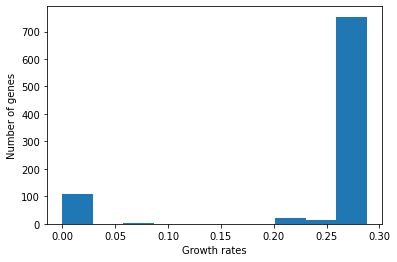

```python
import matplotlib.pyplot as plt
import numpy as np

x = np.array(genes_ids)
y = np.array(grow_rates)

plt.hist(y)
plt.xlabel('Growth rates')
plt.ylabel('Number of genes')
#plt.show()
plt.savefig("distribution.png", dpi=100, bbox_inches='tight',pad_inches=0)
```

```python
import matplotlib.pyplot as plt
import numpy as np

x = np.array(genes_ids)
y = np.array(grow_rates)

fig = plt.figure(figsize=(340, 10))
plt.scatter(x, y)
plt.margins(x=0.001)
plt.xticks(rotation=90)
plt.show()
#plt.savefig("figure.png", dpi=100, bbox_inches='tight',pad_inches=0)
```

[figure not shown]

### Questions

1) Why the distribution of predicted mutant growth rates seems to be bimodal?

2) Can you verify the consistency between gene and reactions knockouts results using a gene or a reaction of your choice?

3) Can you verify essentiality of your gene of choice from the previous excercise using relevant databases (e.g. KEGG and the SGD)?

4) Do you expect these results to change if we change the medium where we are growing our yeast model?

### solution question 2

```python
#from the results of the second chunk of simulations, I know that YJL167W is an essential gene
#I check with genes.get_by_id and I identify the reactions catalysed by this enzyme
model_yeast.genes.get_by_id("YJL167W")
```

| **Gene identifier** | YJL167W |
| --- | --- |
| **Name** | ERG20 |
| **Memory address** | 0x07fd95a9fc190 |
| **Functional** | True |
| **In 2 reaction(s)** | DMATT, GRTT |

```python
#when I selectively knockout the reaction GRTT, I get no growth of my model
with model_yeast as model_yeast:  #not to edit the original model
    grtt = model_yeast.reactions.get_by_id("GRTT")
    grtt.knock_out()
    model_yeast.optimize()
    print('%s blocked (bounds: %s), new growth rate %f' %
            (grtt.id, str(grtt.bounds), model_yeast.objective.value))

#when I selectively knockout the reaction DMATT, I get no growth of my model
with model_yeast as model_yeast:  #not to edit the original model
    dmatt = model_yeast.reactions.get_by_id("DMATT")
    dmatt.knock_out()
    model_yeast.optimize()
    print('%s blocked (bounds: %s), new growth rate %f' %
            (dmatt.id, str(dmatt.bounds), model_yeast.objective.value))
```

```
GRTT blocked (bounds: (0, 0)), new growth rate 0.000000
DMATT blocked (bounds: (0, 0)), new growth rate 0.000000
```

### solution question 3

When we look for YJL167W in the Saccharomyces genome database --> [HERE](https://www.yeastgenome.org/locus/S000003703) , we find out that YJL167W is an essential gene

### solution question 4

Yes, we will go deeper in this in the next notebook :)